# Linear Regression Experiment

November 09, 2021

# Simulation Experiment Recipe

## Objectives

The objective of this simulation experiment is to provide a toy example on how to use `simChef` and showcase the automated R Markdown-generated documentation. For the sake of illustration, this toy simulation experiment studies the performance of linear regression at the surface-level with the sole purpose of facilitating an easy-to-understand walkthrough.

[Typically, the objective of the simulation experiment (and this blurb) will be more scientific than instructive and will warrant additional context/background and domain knowledge.]

## Data Generation

Linear Gaussian DGP

In the Linear Gaussian DGP, we simulate the feature/design matrix $\mathbf{X} \in \mathbb{R}^{n \times p}$ from a normal distribution and the response vector $\mathbf{y} \in \mathbb{R}^n$ from a linear model. Specifically,

$$\begin{gather*}\mathbf{X} \sim N\left(\mathbf{0}, \begin{pmatrix} 1 & \rho \\ \rho & 1 \end{pmatrix}\right), \\\mathbf{y} = \mathbf{X} \boldsymbol{\beta} + \boldsymbol{\epsilon},\\\boldsymbol{\epsilon} \sim N(\mathbf{0}, \sigma^2 \mathbf{I}_n)\end{gather*}$$

**Default Parameters in DGP**

- Number of samples: $n = 200$
- Number of features: $p = 2$
- Correlation among features: $\rho = 0$
- Amount of noise: $\sigma = 1$
- Coefficients: $\boldsymbol{\beta} = (1, 0)^\top$

[In practice, documentation of DGPs should answer the questions “what” and “why”. That is, “what” is the DGP, and “why” are we using/studying it? As this simulation experiment is a contrived example, we omit the “why” here.]

**Function**

```
#> function(n, beta, rho, sigma) {
#>   cov_mat <- matrix(c(1, rho, rho, 1), byrow = T, nrow = 2, ncol = 2)
#>   X <- MASS::mvrnorm(n = n, mu = rep(0, 2), Sigma = cov_mat)
#>   y <- X %*% beta + rnorm(n, sd = sigma)
#>   return(list(X = X, y = y))
#> }
#> <bytecode: 0x7fea6f32fb70>
```

**Input Parameters**

```
#> $n
#> [1] 200
#>
#> $beta
#> [1] 1 0
#>
#> $rho
#> [1] 0
#>
#> $sigma
#> [1] 1
```

## Methods and Evaluation

### Methods

OLS

Given some data $\mathbf{X}$ and $\mathbf{y}$, we fit ordinary least squares (OLS) and examine the p-values for each coefficient in the model. The p-values are computed using a two-sided t-test (see `summary.lm()`).

Elaborating further on the testing, we are interested in testing:

$$\begin{align*}H_0: \beta_i = 0 \quad vs. \quad H_1: \beta_i \neq 0.\end{align*}$$

To test this, we compute the observed T-statistic, defined as

$$\begin{align*}T = \frac{\hat{\beta}_i}{\hat{SE}(\hat{\beta_i})},\end{align*}$$

and then compute the two-sided p-value under the t distribution with $n - p - 1$ degrees of freedom. If the p-value is lower than some significance value $\alpha$, then there is sufficient evidence to reject the null hypothesis $H_0$. Otherwise, there is not sufficient evidence, and we fail to reject the null hypothesis.

[In practice, documentation of methods should answer the questions “what” and “why”. That is, “what” is the method, and “why” are we using/studying it? As this simulation experiment is a contrived example, we omit the “why” here.]

**Function**

```
#> function(X, y, cols = c("X1", "X2")) {
#>   lm_fit <- lm(y ~ X)
#>   pvals <- summary(lm_fit)$coefficients[cols, "Pr(>|t|)"] %>%
#>     setNames(paste(names(.), "p-value"))
#>   return(pvals)
#> }
#> <bytecode: 0x7fea6eb74bc0>
```

**Input Parameters**

```
#> named list()
```

### Evaluation

Rejection Prob. (alpha = 0.1)

We define the rejection probability as the proportion of repetitions in the simulation experiment that result in a p-value $\leq \alpha$. Here, we choose to set the significance level $\alpha = 0.1$.

[In practice, documentation of evaluation metrics should answer the questions “what” and “why”. That is, “what” is the metric, and “why” are we using/studying it? As this simulation experiment is a contrived example, we omit the “why” here.]

**Function**

```
#> function(fit_results, alpha = 0.05) {
#>   group_vars <- c(".dgp_name", ".method_name")
#>   eval_out <- fit_results %>%
#>     dplyr::group_by(across({{group_vars}})) %>%
#>     dplyr::summarise(
#>       `X1 Reject Prob.` = mean(`X1 p-value` < alpha),
#>       `X2 Reject Prob.` = mean(`X2 p-value` < alpha)
#>     )
#>   return(eval_out)
#> }
```

**Input Parameters**

```
#> $alpha
#> [1] 0.1
```

## Visualizations

Power

To examine the power of the test, we plot the rejection probability as a function of $\alpha$, that is, $\mathbb{P}(\text{p-value} \leq \alpha)$ vs. $\alpha$. If the coefficient is non-zero in the underlying DGP, then a larger AUC would indicate better performance in terms of the power. We will primarily focus on plotting the power of the first coefficient $\beta_1$.

[In practice, documentation of the plotters should answer the questions “what” and “why”. That is, “what” is the plot, and “why” are we using/studying it? As this simulation experiment is a contrived example, we omit the “why” here.]

**Function**

```
#> function(fit_results, col = "X1") {
#>   plt <- ggplot2::ggplot(fit_results) +
#>     ggplot2::aes(x = .data[[paste(col, "p-value")]],
#>                  color = as.factor(.method_name)) +
#>     ggplot2::geom_abline(slope = 1, intercept = 0,
#>                          color = "darkgray", linetype = "solid", size = 1) +
#>     ggplot2::stat_ecdf(size = 1) +
#>     ggplot2::scale_x_continuous(limits = c(0, 1)) +
#>     ggplot2::labs(x = "t", y = "P( p-value \u2264 t )",
#>                   linetype = "", color = "Method")
#>   return(plt)
#> }
```

**Input Parameters**

```
#> named list()
```

# Base Linear Regression Experiment

### Rejection Prob. (alpha = 0.1)

|  | .dgp_name | .method_name | X1 Reject Prob. | X2 Reject Prob. |
| --- | --- | --- | --- | --- |
| 1 | Linear Gaussian DGP | OLS | 1.00 | 0.12 |

### Power

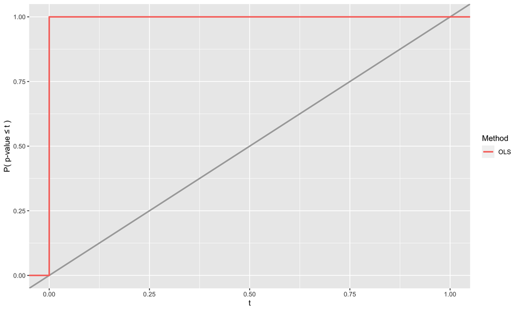